# Hipp vs Stri

Diego Arturo

13 de junio de 2020

## 1. Downloading BAM's and Raw count matrix.

The 32 BAM's were retrieved from the SRP_Diego/Allison drive with gdown function in the shell command line, using the file ID.

```bash
#gdown https://drive.google.com/uc?id=1xGvBt6zEq6TwwVjue6w0UrlKRK9BLuNR
```

Next, the BAM files were sorted and indexed for futher processing.

```bash
#for bam in *.bam; do base=$(echo $bam | cut -f1,2 -d"."); echo -e "....$base......\n"; samtools sort $bam > ${base}.sorted.bam; samtools index ${base}.sorted.bam > ${base}.sorted.idx.bam; done
```

[output not shown]

Finally, the BAM files were feeded to featureCounts, to retrieve the raw counts matrix. This program requieres the BAM files and the anottated genome of interest, in GFT format. Two anottations were donwloaded for comparison, each from a diferent ensemble release: *Mus_musculus.GRCm38.85.gtf* Mus_musculus.GRCm38.100.gtf

```bash
#featureCounts -M -t gene -T 4 -s 0 --largestOverlap -O -a Mus_musculus.GRCm38.85.gtf -o Results/Raw_LO_Ocounts_85unstrgenemut.txt  Aligments/*sorted.bam
#featureCounts -M -t gene -T 4 -s 0 --largestOverlap -O -a Mus_musculus.GRCm38.100.gtf -o Results/Raw_LO_Ocounts_100unstrgenemut.txt  Aligments/*sorted.bam
```

This two line output 2 matrixes that cover abour 90% of each BAM file's reads.

```r
Raw_100 <- read.table("C:/Users/HP/Desktop/Graff_Burns/Neuroepigenetics and Memory/DifExpAna/Raw_LO_Ocounts_100unstrgenemut.txt", comment.char="#",header = T)
Raw_85 <- read.table("C:/Users/HP/Desktop/Graff_Burns/Neuroepigenetics and Memory/DifExpAna/Raw_LO_Ocounts_85unstrgenemut.txt", comment.char="#",header = T)

Names<-c("Hpp_Hi_Sho_r1","Str_Hi_Sho_r1","Hpp_Hi_Sho_r2","Str_Hi_Sho_r2",
         "Hpp_Vh_Sho_r1","Str_Vh_Sho_r1","Hpp_Vh_Sho_r2","Str_Vh_Sho_r2",
         "Hpp_Hi_Con_r1","Str_Hi_Con_r1","Hpp_Hi_Con_r2","Str_Hi_Con_r2",
         "Hpp_Vh_Con_r1","Str_Vh_Con_r1","Hpp_Vh_Con_r2","Str_Vh_Con_r2",
         "Hpp_Vh_Con_r3","Str_Vh_Con_r3","Hpp_Vh_Con_r4","Str_Vh_Con_r4",
         "Hpp_Hi_Con_r3","Str_Hi_Con_r3","Hpp_Hi_Con_r4","Str_Hi_Con_r4",
         "Hpp_Vh_Sho_r3","Str_Vh_Sho_r3","Hpp_Vh_Sho_r4","Str_Vh_Sho_r4",
         "Hpp_Hi_Sho_r3","Str_Hi_Sho_r3","Hpp_Hi_Sho_r4","Str_Hi_Sho_r4")

colnames(Raw_100)[7:length(colnames(Raw_100))]<- Names
colnames(Raw_85)[7:length(colnames(Raw_85))]<- Names

row.names(Raw_100)<-Raw_100$Geneid
Raw_100<-Raw_100[7:length(colnames(Raw_100))]

row.names(Raw_85)<-Raw_85$Geneid
Raw_85<-Raw_85[7:length(colnames(Raw_85))]

head(Raw_85)
```

```
##                    Hpp_Hi_Sho_r1 Str_Hi_Sho_r1 Hpp_Hi_Sho_r2 Str_Hi_Sho_r2
## ENSMUSG00000102693             1             0             0             1
## ENSMUSG00000064842             0             0             0             0
## ENSMUSG00000051951         12069          5616          2474          7758
## ENSMUSG00000102851             2             2             1             3
## ENSMUSG00000103377           111            44            31            65
## ENSMUSG00000104017            68            23            24            31
##                    Hpp_Vh_Sho_r1 Str_Vh_Sho_r1 Hpp_Vh_Sho_r2 Str_Vh_Sho_r2
## ENSMUSG00000102693             0             0             0             1
## ENSMUSG00000064842             0             0             0             0
## ENSMUSG00000051951         11480          7611         15623         12777
## ENSMUSG00000102851             3             1             2             3
## ENSMUSG00000103377            91            59           111            78
## ENSMUSG00000104017            65            37            83            58
##                    Hpp_Hi_Con_r1 Str_Hi_Con_r1 Hpp_Hi_Con_r2 Str_Hi_Con_r2
## ENSMUSG00000102693             0             0             0             0
## ENSMUSG00000064842             0             0             0             0
## ENSMUSG00000051951          9132          6422          7922          5520
## ENSMUSG00000102851             9             3             4             8
## ENSMUSG00000103377            69            48            58            34
## ENSMUSG00000104017            30            38            35            29
##                    Hpp_Vh_Con_r1 Str_Vh_Con_r1 Hpp_Vh_Con_r2 Str_Vh_Con_r2
## ENSMUSG00000102693             0             0             0             0
## ENSMUSG00000064842             0             0             0             0
## ENSMUSG00000051951         13535          6933         16359          9117
## ENSMUSG00000102851             4             2             7             2
## ENSMUSG00000103377           103            54           146            71
## ENSMUSG00000104017            64            14           112            35
##                    Hpp_Vh_Con_r3 Str_Vh_Con_r3 Hpp_Vh_Con_r4 Str_Vh_Con_r4
## ENSMUSG00000102693             0             0             0             0
## ENSMUSG00000064842             0             0             0             0
## ENSMUSG00000051951         17311         10534         18217         13280
## ENSMUSG00000102851            10             5             7             7
## ENSMUSG00000103377           144            71           166           122
## ENSMUSG00000104017           109            52           104            95
##                    Hpp_Hi_Con_r3 Str_Hi_Con_r3 Hpp_Hi_Con_r4 Str_Hi_Con_r4
## ENSMUSG00000102693             1             1             0             0
## ENSMUSG00000064842             0             0             0             0
## ENSMUSG00000051951         12684          7072          7897          8672
## ENSMUSG00000102851             9             5             3             5
## ENSMUSG00000103377           133            63            58            83
## ENSMUSG00000104017            82            43            35            57
##                    Hpp_Vh_Sho_r3 Str_Vh_Sho_r3 Hpp_Vh_Sho_r4 Str_Vh_Sho_r4
## ENSMUSG00000102693             0             1             0             0
## ENSMUSG00000064842             0             0             0             0
## ENSMUSG00000051951         11949          9511          9760         15620
## ENSMUSG00000102851             6             6             1             6
## ENSMUSG00000103377            94            63            70           120
## ENSMUSG00000104017            49            42            42            81
##                    Hpp_Hi_Sho_r3 Str_Hi_Sho_r3 Hpp_Hi_Sho_r4 Str_Hi_Sho_r4
## ENSMUSG00000102693             0             0             0             0
## ENSMUSG00000064842             0             0             0             0
## ENSMUSG00000051951          9599          5333          8535          4246
## ENSMUSG00000102851             5             6             5             5
## ENSMUSG00000103377            80            47            76            39
## ENSMUSG00000104017            31            28            37            26
```

```r
dim(Raw_100)[1] # Number of genes
```

```
## [1] 55487
```

```r
dim(Raw_85)[1]
```

```
## [1] 48526
```

## 2: Processing Matrixes for edgeR and explorative analysis.

The nex step is filtering the matrixes to trash those genese that are poorly expressed and can affect the analysis.

```r
library(edgeR)
keep100<-rowSums(cpm(Raw_100)>=1)>=2
keep85<-rowSums(cpm(Raw_85)>=1)>=2

table(keep100)
```

```
## keep100
## FALSE  TRUE
## 35290 20197
```

```r
table(keep85)
```

```
## keep85
## FALSE  TRUE
## 29285 19241
```

```r
Counts100<-Raw_100[keep100,]
Counts85<-Raw_85[keep85,]

dim(Counts100)[1]
```

```
## [1] 20197
```

```r
dim(Counts85)[1]
```

```
## [1] 19241
```

Let us see general expression pattern of the data and see how the clusterize in a unsupervised algorithm.

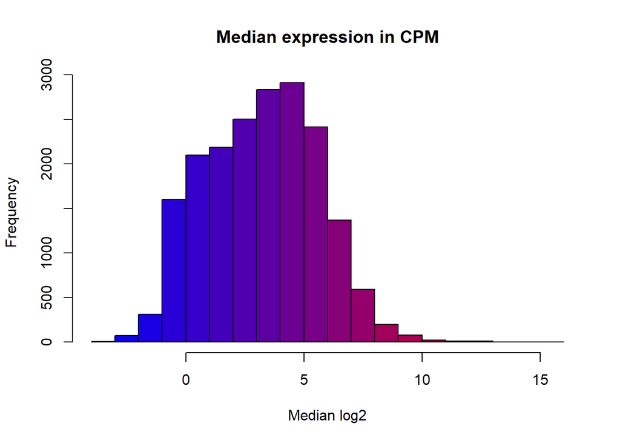

```r
cpm_log <- cpm(Counts85,log = T)
medial_log<- apply(cpm_log, 1, median)
blue_red<- colorRampPalette(c("blue","red"))
hist(medial_log,main="Median expression in CPM",xlab="Median log2",ylab = "Frequency",col = blue_red(20))
```

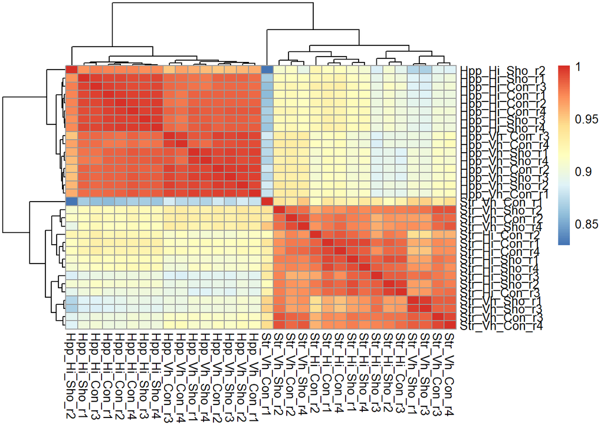

```r
library(pheatmap)
pheatmap(cor(cpm_log))
```

Due to the unclusterization and outlier characteristics the sample named Str_Vh_Con_r1, from the 7823 mice, will be removed.

```r
Names2<- Names[!Names=="Str_Vh_Con_r1"]
Counts85<-Counts85[,Names2]
```

Next, the grouping must be created. This are target and non target areas and represent, HS(Hi_Sho), VS(Vh_Sho), HC(Hi_Con) and VC(Vh_Con) groups, respectively.

```r
group <-factor(sub("_r.+","",colnames(Counts85)))
group
```

```
##  [1] Hpp_Hi_Sho Str_Hi_Sho Hpp_Hi_Sho Str_Hi_Sho Hpp_Vh_Sho Str_Vh_Sho
##  [7] Hpp_Vh_Sho Str_Vh_Sho Hpp_Hi_Con Str_Hi_Con Hpp_Hi_Con Str_Hi_Con
## [13] Hpp_Vh_Con Hpp_Vh_Con Str_Vh_Con Hpp_Vh_Con Str_Vh_Con Hpp_Vh_Con
## [19] Str_Vh_Con Hpp_Hi_Con Str_Hi_Con Hpp_Hi_Con Str_Hi_Con Hpp_Vh_Sho
## [25] Str_Vh_Sho Hpp_Vh_Sho Str_Vh_Sho Hpp_Hi_Sho Str_Hi_Sho Hpp_Hi_Sho
## [31] Str_Hi_Sho
## 8 Levels: Hpp_Hi_Con Hpp_Hi_Sho Hpp_Vh_Con Hpp_Vh_Sho ... Str_Vh_Sho
```

Crafting EdeR object.

```r
dge85<- DGEList(counts = Counts85, group = group)
dge85<-calcNormFactors(dge85)
dge85$samples
```

```
##                    group lib.size norm.factors
## Hpp_Hi_Sho_r1 Hpp_Hi_Sho 60230209    1.0826272
## Str_Hi_Sho_r1 Str_Hi_Sho 69264342    1.0699469
## Hpp_Hi_Sho_r2 Hpp_Hi_Sho 80910100    0.1928975
## Str_Hi_Sho_r2 Str_Hi_Sho 63339498    1.0394668
## Hpp_Vh_Sho_r1 Hpp_Vh_Sho 62866176    1.1409307
## Str_Vh_Sho_r1 Str_Vh_Sho 72204763    0.8555798
## Hpp_Vh_Sho_r2 Hpp_Vh_Sho 64044804    1.2086285
## Str_Vh_Sho_r2 Str_Vh_Sho 67611962    1.1014463
## Hpp_Hi_Con_r1 Hpp_Hi_Con 59731929    1.1076294
## Str_Hi_Con_r1 Str_Hi_Con 68724122    1.0409479
## Hpp_Hi_Con_r2 Hpp_Hi_Con 62977031    1.0473237
## Str_Hi_Con_r2 Str_Hi_Con 72231544    0.7502240
## Hpp_Vh_Con_r1 Hpp_Vh_Con 67678887    1.1024951
## Hpp_Vh_Con_r2 Hpp_Vh_Con 70049556    1.2298928
## Str_Vh_Con_r2 Str_Vh_Con 65397095    1.0002420
## Hpp_Vh_Con_r3 Hpp_Vh_Con 58216098    1.2502017
## Str_Vh_Con_r3 Str_Vh_Con 70534220    1.1211042
## Hpp_Vh_Con_r4 Hpp_Vh_Con 62936053    1.0945949
## Str_Vh_Con_r4 Str_Vh_Con 68206226    1.1201573
## Hpp_Hi_Con_r3 Hpp_Hi_Con 59882331    1.1023256
## Str_Hi_Con_r3 Str_Hi_Con 56474347    1.0292815
## Hpp_Hi_Con_r4 Hpp_Hi_Con 61631971    0.9745172
## Str_Hi_Con_r4 Str_Hi_Con 69098158    1.1005185
## Hpp_Vh_Sho_r3 Hpp_Vh_Sho 59543047    1.2297143
## Str_Vh_Sho_r3 Str_Vh_Sho 80331868    0.8018254
## Hpp_Vh_Sho_r4 Hpp_Vh_Sho 69051645    1.1959469
## Str_Vh_Sho_r4 Str_Vh_Sho 72357838    1.1517380
## Hpp_Hi_Sho_r3 Hpp_Hi_Sho 60509813    1.0729736
## Str_Hi_Sho_r3 Str_Hi_Sho 77046311    0.8714344
## Hpp_Hi_Sho_r4 Hpp_Hi_Sho 60075757    1.0765365
## Str_Hi_Sho_r4 Str_Hi_Sho 64822671    0.9432126
```

Now let's see the data represented in MD plots.

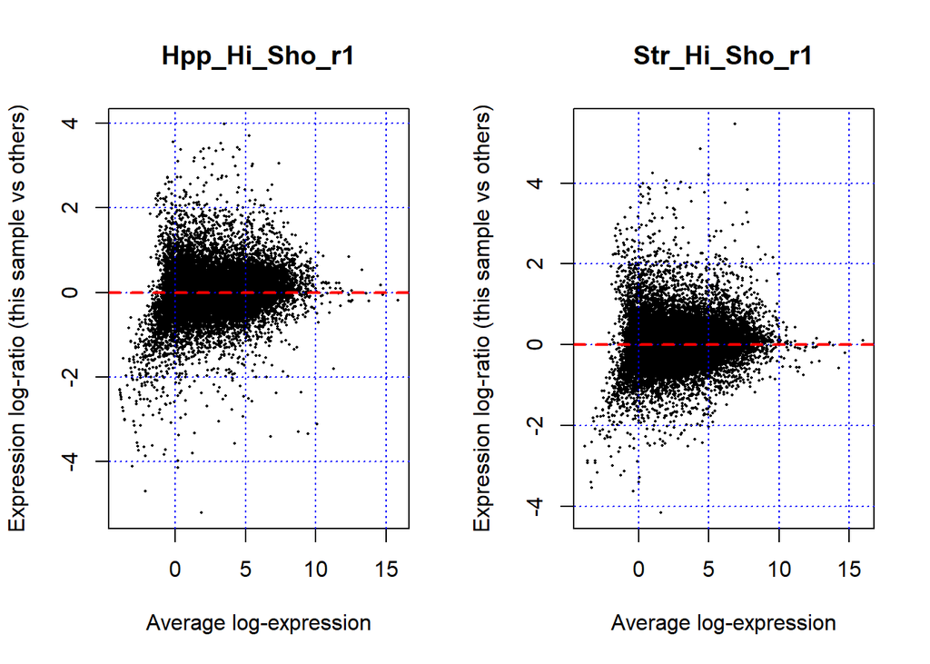

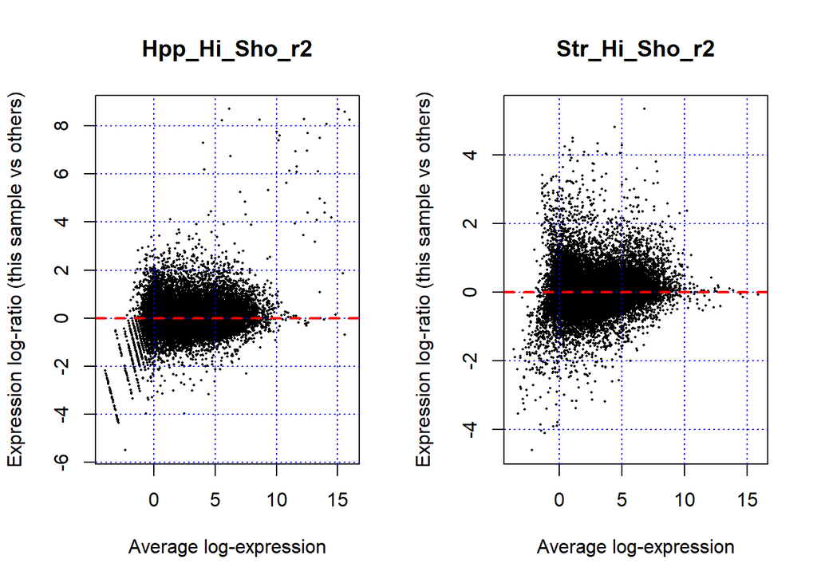

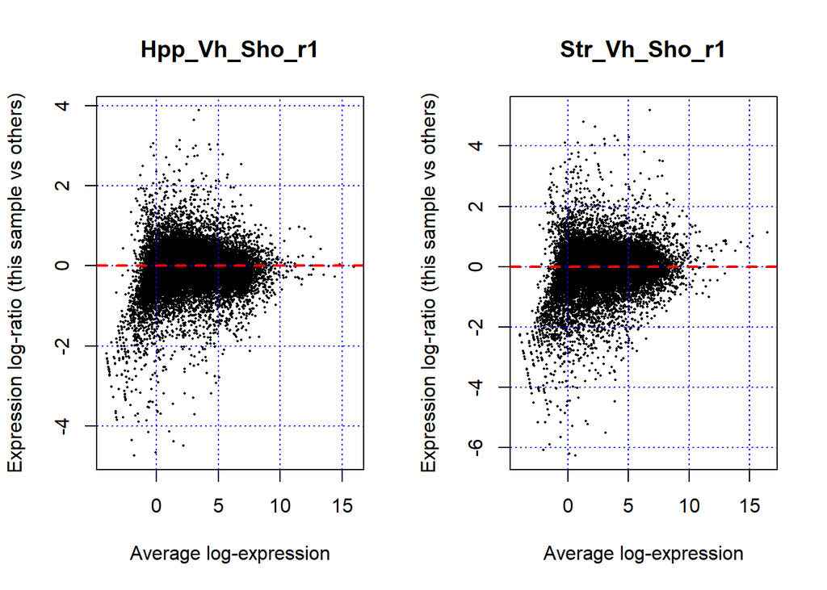

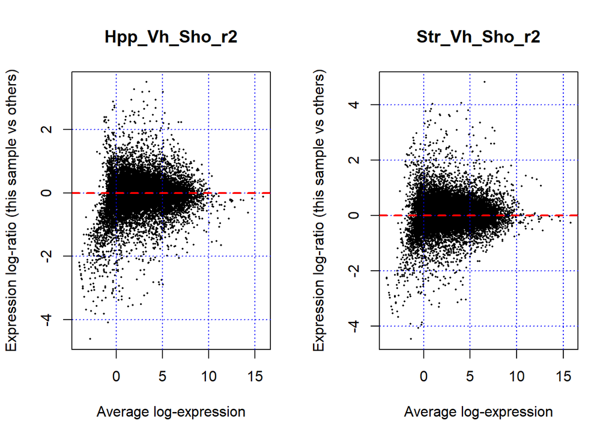

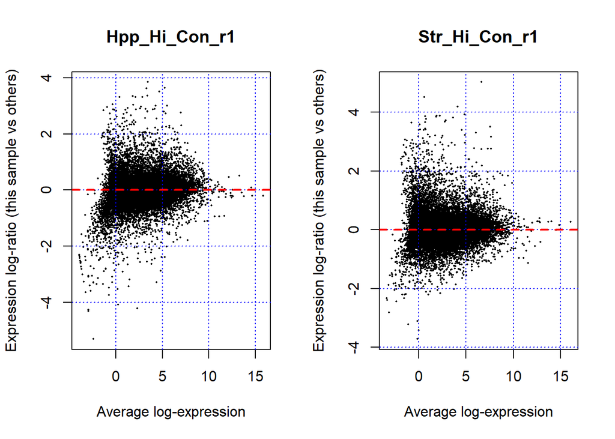

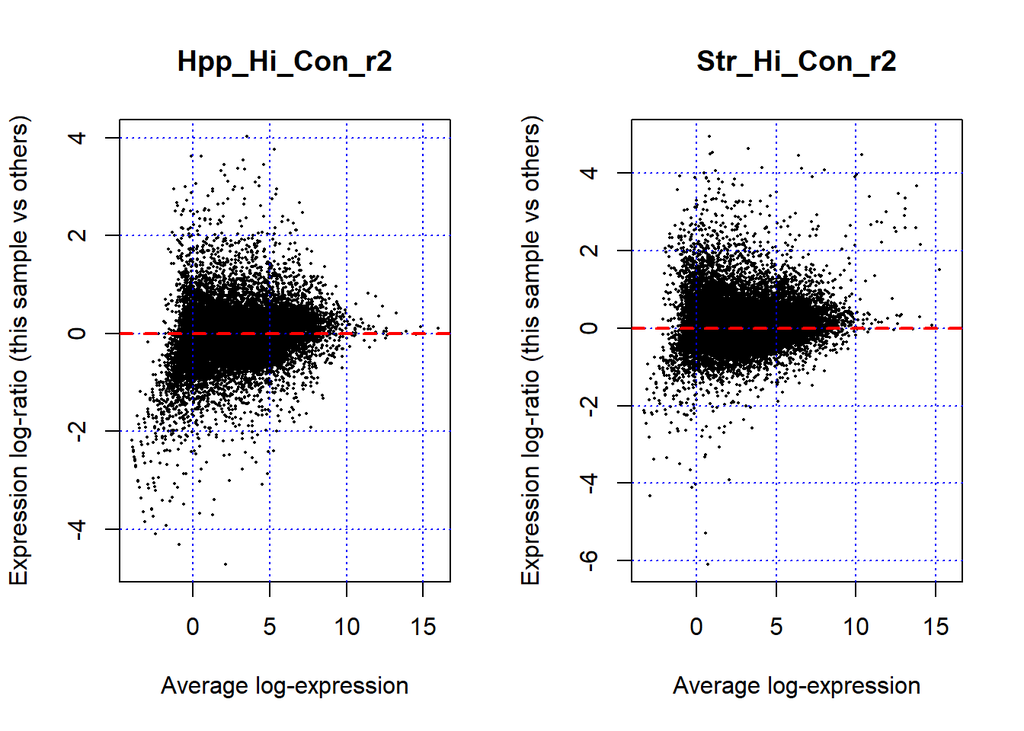

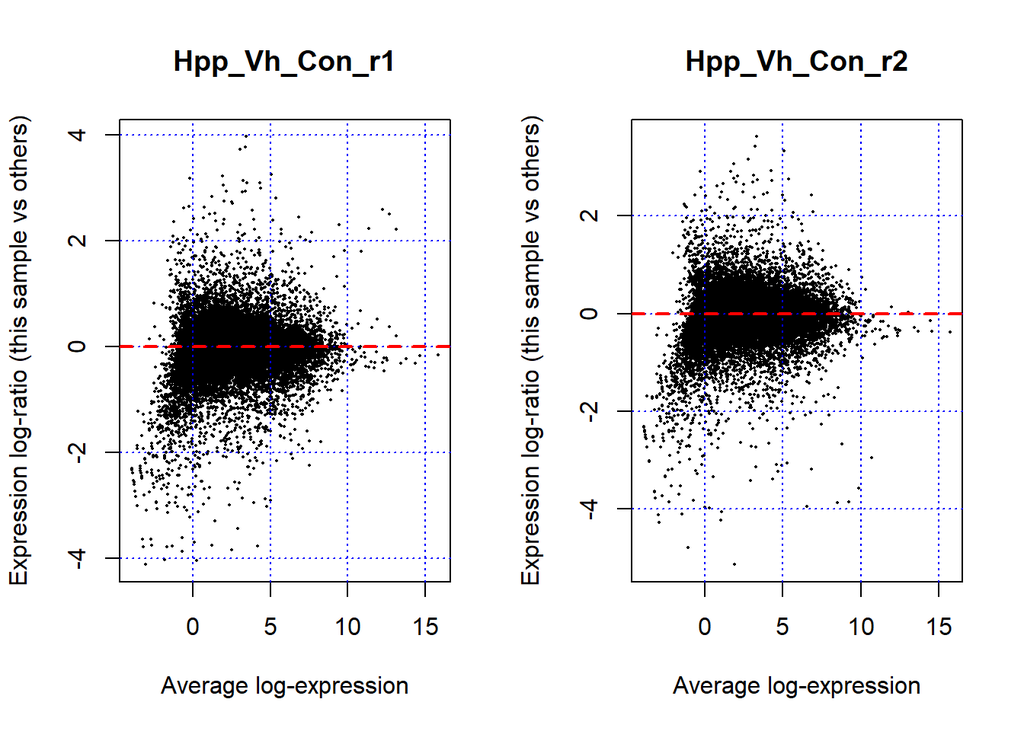

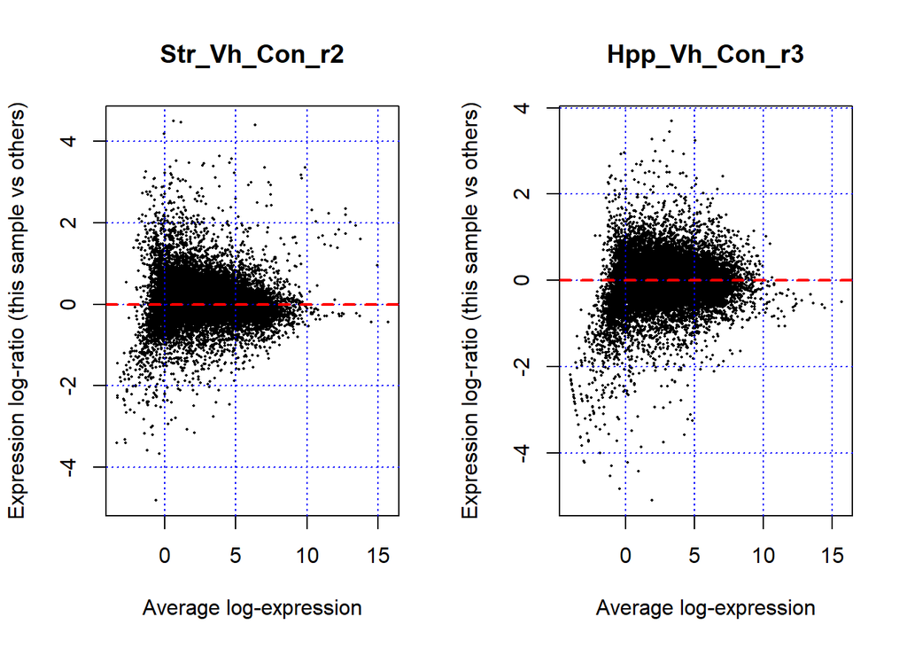

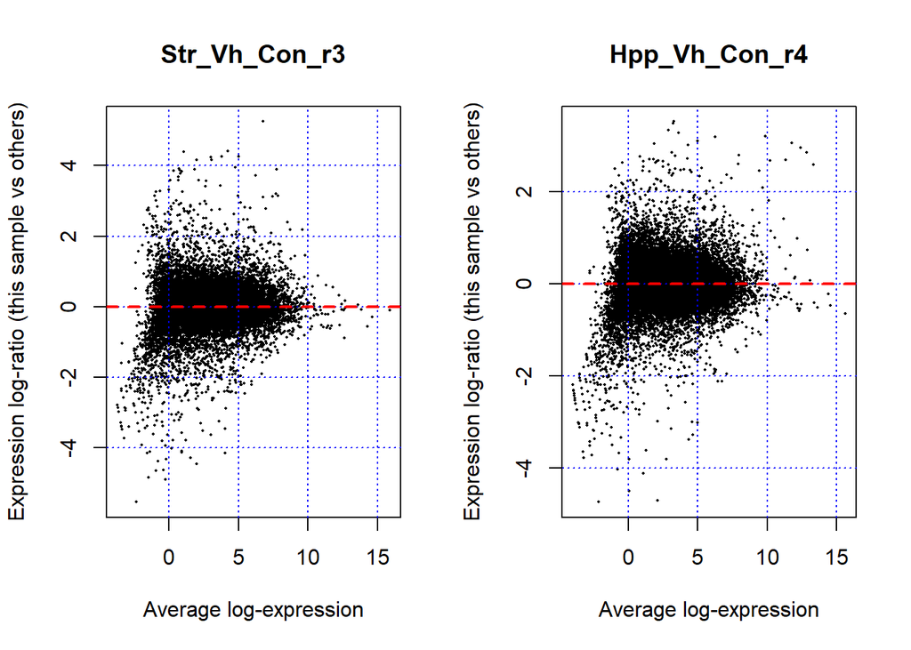

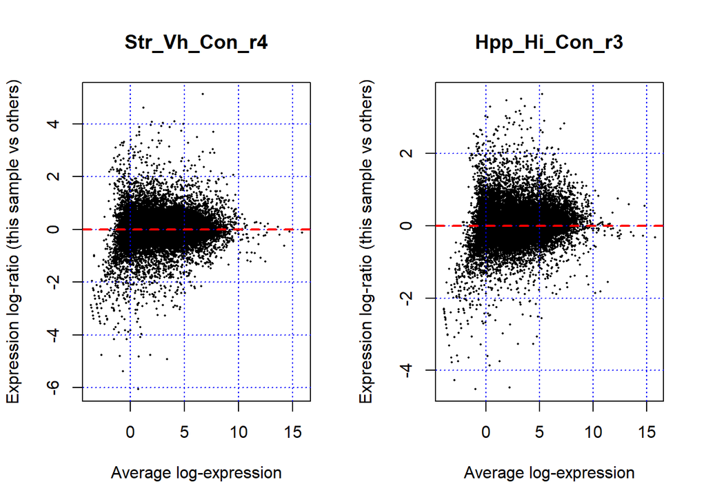

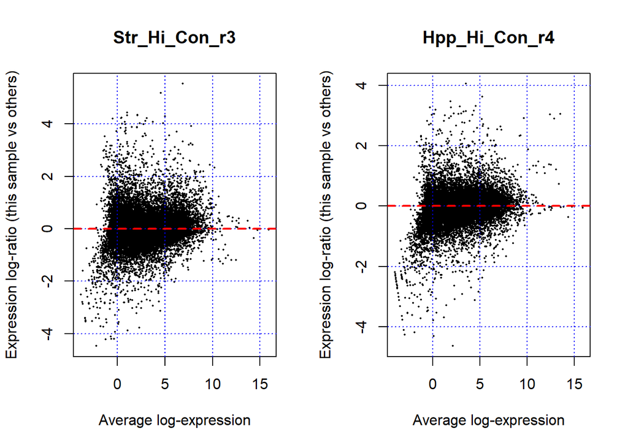

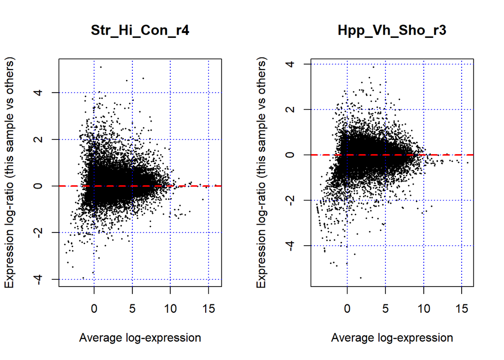

[4 more figures not shown]

```r
par(mfrow =c(1,2))
for (i in c(1:31)){
  plotMD(cpm(dge85,log = TRUE),column = i)
  grid(col = "blue")
  abline(h=0,col="red",lty=2,lwd=2)
}
```

Then, in the MDS transformation plot.

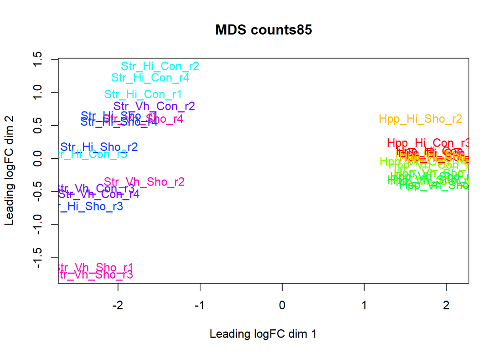

```r
cols<-rainbow(length(levels(group)))
names(cols)<-levels(group)

plotMDS(dge85, col=cols[dge85$samples$group], labels=colnames(dge85$counts), main="MDS counts85")
```

##3: Experimental model desing

```r
design85<- model.matrix(~0+dge85$samples$group)
colnames(design85)<-levels(dge85$samples$group)
design85
```

```
##    Hpp_Hi_Con Hpp_Hi_Sho Hpp_Vh_Con Hpp_Vh_Sho Str_Hi_Con Str_Hi_Sho Str_Vh_Con
## 1           0          1          0          0          0          0          0
## 2           0          0          0          0          0          1          0
## 3           0          1          0          0          0          0          0
## 4           0          0          0          0          0          1          0
## 5           0          0          0          1          0          0          0
## 6           0          0          0          0          0          0          0
## 7           0          0          0          1          0          0          0
## 8           0          0          0          0          0          0          0
## 9           1          0          0          0          0          0          0
## 10          0          0          0          0          1          0          0
## 11          1          0          0          0          0          0          0
## 12          0          0          0          0          1          0          0
## 13          0          0          1          0          0          0          0
## 14          0          0          1          0          0          0          0
```

[output cut: 54 more lines]

## 4: Dispersion estimates

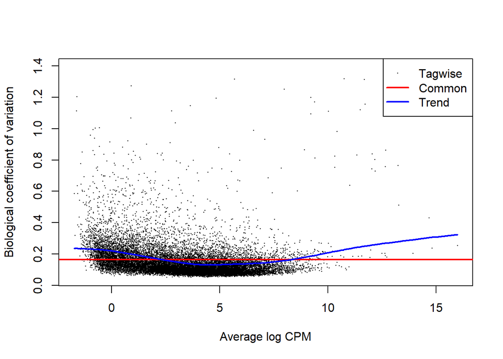

```r
dge85<- estimateDisp(dge85,design = design85,robust = T)
plotBCV(dge85)
```

From this dispersion plot, the most accurate dispersion to use is the Trend, beacause it represents a good behaivour of the higly expressed genes and easily catch them with more realistic values.

## 5: Differential Expresion Analysis.

Multiple question are adressed in this part (regarding Hippocampus), so they are be enlisted:

- activated(Hi_Sho) vs control(Vh_Con).
- activated(Hi_Sho) vs primed (Hi_Con).
- activated(Hi_Sho) vs non-primed (Vh_Sho).

```r
contrast<-makeContrasts(
  "Activated_effect"="Hpp_Hi_Sho - Hpp_Vh_Con",
  "Activated_primed"="Hpp_Hi_Sho - Hpp_Hi_Con",
  "Activated_nonprimed"="Hpp_Hi_Sho - Hpp_Vh_Sho",
  levels = dge85$design
)
contrast
```

```
##             Contrasts
## Levels       Activated_effect Activated_primed Activated_nonprimed
##   Hpp_Hi_Con                0               -1                   0
##   Hpp_Hi_Sho                1                1                   1
##   Hpp_Vh_Con               -1                0                   0
##   Hpp_Vh_Sho                0                0                  -1
##   Str_Hi_Con                0                0                   0
##   Str_Hi_Sho                0                0                   0
##   Str_Vh_Con                0                0                   0
##   Str_Vh_Sho                0                0                   0
```

```r
contHS_VC<- contrast[,1]

contHS_HC<- contrast[,2]

contHS_VS<- contrast[,3]
```

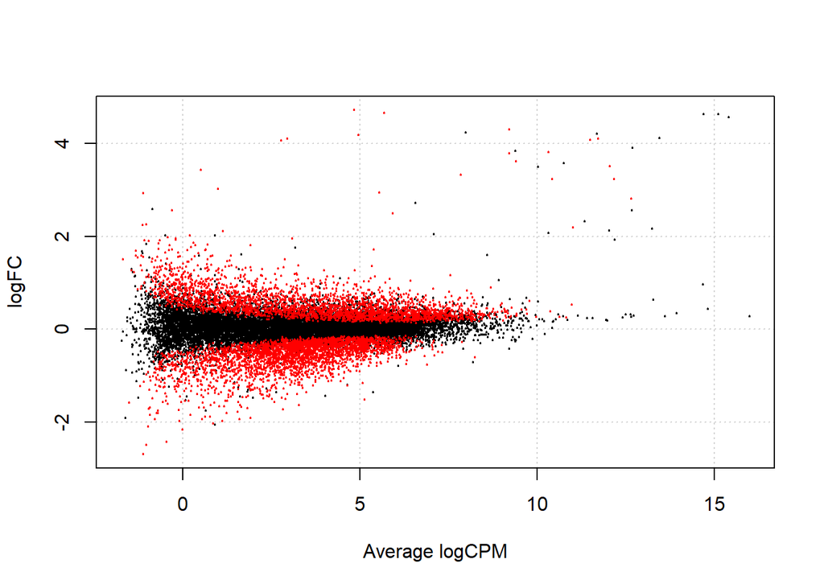

```r
glm<-glmQLFit(dge85,dispersion = dge85$trended.dispersion,robust = T)
glm2<-glmQLFit(dge85,dispersion = dge85$tagwise.dispersion)
glm3<-glmQLFit(dge85,dispersion = dge85$common.dispersion)

LFTHS_VC<-glmQLFTest(glm,contrast =  contHS_VC)
LFTHS_HC<-glmQLFTest(glm2,contrast =  contHS_HC)
LFTHS_VS<-glmQLFTest(glm,contrast =  contHS_VS)

dt.HS_VC<-decideTestsDGE(LFTHS_VC,adjust.method = "BH",p.value = 0.05,lfc = 0)
deGenes<- rownames(LFTHS_VC)[dt.HS_VC !=0]
plotSmear(LFTHS_VC,de.tags = deGenes)
```

```r
table(dt.HS_VC)
```

```
## dt.HS_VC
##    -1     0     1
##  3079 13278  2884
```

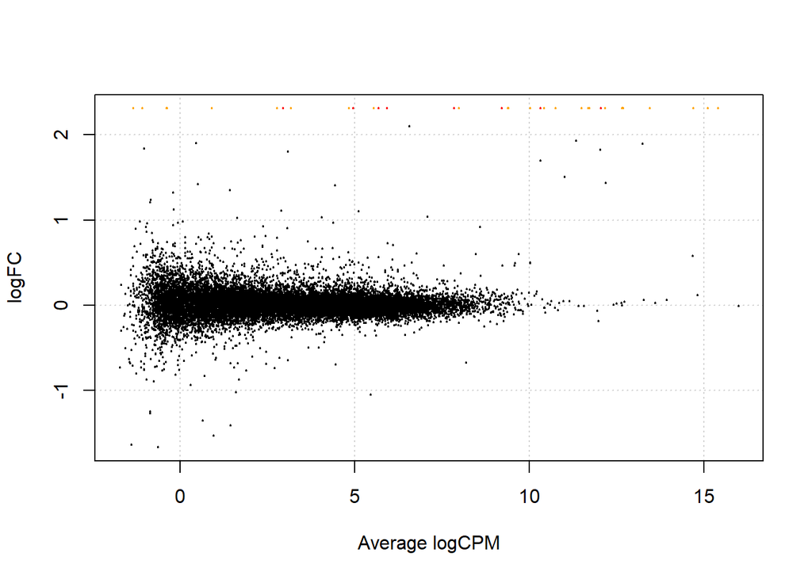

```r
dt.HS_HC<-decideTestsDGE(LFTHS_HC,adjust.method = "BH",p.value = 0.05,lfc = 0)
deGenes<- rownames(LFTHS_HC)[dt.HS_HC !=0]
plotSmear(LFTHS_HC,de.tags = deGenes)
```

```r
table(dt.HS_HC)
```

```
## dt.HS_HC
##     0     1
## 19233     8
```

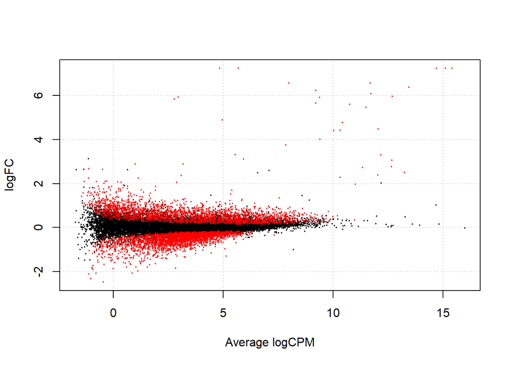

```r
dt.HS_VS<-decideTestsDGE(LFTHS_VS,adjust.method = "BH",p.value = 0.05,lfc = 0)
deGenes<- rownames(LFTHS_VS)[dt.HS_VS !=0]
plotSmear(LFTHS_VS,de.tags = deGenes)
```

```r
table(dt.HS_VS)
```

```
## dt.HS_VS
##    -1     0     1
##  2752 14044  2445
```

```r
library(biomaRt)
DGE.HS_VC<-topTags(LFTHS_VC,n=Inf)$table
mart <- useDataset(dataset = "mmusculus_gene_ensembl", useMart("ensembl"))
Genes<- getBM(filters= "ensembl_gene_id", attributes=
c("ensembl_gene_id","external_gene_name"),values=sort(row.names(DGE.HS_VC)),mart= mart)

DGE.HS_VC$ensembl_gene_id<-row.names(DGE.HS_VC)
DGE.HS_VC<-merge(DGE.HS_VC,Genes,by="ensembl_gene_id")
write.csv(DGE.HS_VC,"DGE.HS_VC.csv")
head(DGE.HS_VC)
```

```
##      ensembl_gene_id       logFC    logCPM          F      PValue         FDR
## 1 ENSMUSG00000000001 -0.16512427 4.7546566  2.8170753 0.104731676 0.208154342
## 2 ENSMUSG00000000028 -0.17767920 0.2308655  1.0442723 0.315841803 0.462112024
## 3 ENSMUSG00000000037 -0.76016631 0.4179607 12.3900227 0.001541803 0.008497803
## 4 ENSMUSG00000000049  0.39858076 1.7256776  6.8737857 0.014158447 0.046647718
## 5 ENSMUSG00000000056 -0.04734403 5.1346188  0.1816023 0.673356571 0.781561375
## 6 ENSMUSG00000000058  0.13592574 3.2441450  0.7059169 0.408152610 0.553461314
##   external_gene_name
## 1              Gnai3
## 2              Cdc45
## 3              Scml2
## 4               Apoh
## 5               Narf
## 6               Cav2
```

```r
DGE.HS_HC<-topTags(LFTHS_HC,n=Inf)$table
DGE.HS_HC$ensembl_gene_id<-row.names(DGE.HS_HC)
DGE.HS_HC<-merge(DGE.HS_HC,Genes,by="ensembl_gene_id")
write.csv(DGE.HS_HC,"DGE.HS_HC.csv")
head(DGE.HS_HC)
```

```
##      ensembl_gene_id        logFC    logCPM           F    PValue FDR
## 1 ENSMUSG00000000001 -0.051557944 4.7546566 0.270590126 0.6029364   1
## 2 ENSMUSG00000000028  0.176245399 0.2308655 0.906839899 0.3409548   1
## 3 ENSMUSG00000000037  0.077581083 0.4179607 0.122826696 0.7259889   1
## 4 ENSMUSG00000000049  0.102982112 1.7256776 0.448087976 0.5032447   1
## 5 ENSMUSG00000000056 -0.004786499 5.1346188 0.001846701 0.9657229   1
## 6 ENSMUSG00000000058 -0.157324211 3.2441450 0.989009785 0.3199851   1
##   external_gene_name
## 1              Gnai3
## 2              Cdc45
## 3              Scml2
## 4               Apoh
## 5               Narf
## 6               Cav2
```

```r
DGE.HS_VS<-topTags(LFTHS_VS,n=Inf)$table
DGE.HS_VS$ensembl_gene_id<-row.names(DGE.HS_VS)
DGE.HS_VS<-merge(DGE.HS_VS,Genes,by="ensembl_gene_id")
write.csv(DGE.HS_VS,"DGE.HS_VS.csv")
head(DGE.HS_VS)
```

```
##      ensembl_gene_id        logFC    logCPM            F      PValue        FDR
## 1 ENSMUSG00000000001  0.000137609 4.7546566 1.964637e-06 0.998891881 0.99951525
## 2 ENSMUSG00000000028 -0.147676116 0.2308655 7.210886e-01 0.403206242 0.57689555
## 3 ENSMUSG00000000037 -0.290251594 0.4179607 1.768948e+00 0.194568428 0.35284553
## 4 ENSMUSG00000000049  0.424516560 1.7256776 7.794636e+00 0.009476358 0.03818526
## 5 ENSMUSG00000000056 -0.075412189 5.1346188 4.608913e-01 0.502949261 0.66661478
## 6 ENSMUSG00000000058  0.210049936 3.2441450 1.683144e+00 0.205440574 0.36699304
##   external_gene_name
## 1              Gnai3
## 2              Cdc45
## 3              Scml2
## 4               Apoh
## 5               Narf
## 6               Cav2
```

# Ontology characterization of Up-regulated Genes.

Now, I will be assessed whether there is an overrepresenation of ontology characterization in the up-regulated genes.

```r
library(GO.db)
library(org.Mm.eg.db)
library(clusterProfiler)
library(AnnotationHub)
library(ensembldb)
library(tidyverse)
```

```r
UpDGE.HS_VC<-DGE.HS_VC[DGE.HS_VC$logFC>=1 & DGE.HS_VC$FDR <0.05,]$ensembl_gene_id
UpDGE.HS_HC<-DGE.HS_HC[DGE.HS_HC$logFC>=1 & DGE.HS_HC$FDR <0.05,]$ensembl_gene_id
UpDGE.HS_VS<-DGE.HS_VS[DGE.HS_VS$logFC>=1 & DGE.HS_VS$FDR <0.05,]$ensembl_gene_id
DownDGE.HS_VC<-DGE.HS_VC[DGE.HS_VC$logFC<=-1 & DGE.HS_VC$FDR <0.05,]$ensembl_gene_id
DownDGE.HS_VS<-DGE.HS_VS[DGE.HS_VS$logFC<=-1 & DGE.HS_VS$FDR <0.05,]$ensembl_gene_id
```

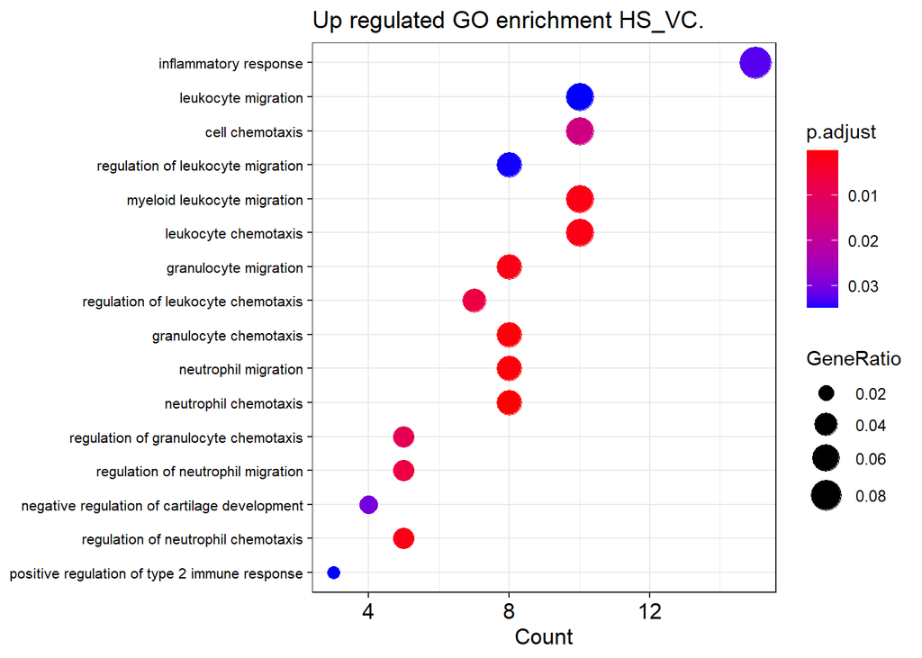

```r
no_dup<-which(duplicated(UpDGE.HS_VC)== FALSE)
UpDGE.HS_VC<-UpDGE.HS_VC[no_dup]

allOE_genes<- as.character(row.names(Counts85))
egoHS_VC<-enrichGO(gene = as.character(UpDGE.HS_VC),
                   universe = allOE_genes,
                   keyType = "ENSEMBL",
                   OrgDb =org.Mm.eg.db,
                   ont = "BP",
                   pAdjustMethod = "BH",
                   qvalueCutoff = 0.05,
                   readable = T)

Summ.ego.Up.HS_VC<-data.frame(egoHS_VC)

dotplot(object=egoHS_VC,x="count",orderBy="BgRatio",showCategory=50) + theme(axis.text.y = element_text(size = 7.7))+ ggtitle("Up regulated GO enrichment HS_VC.")
```

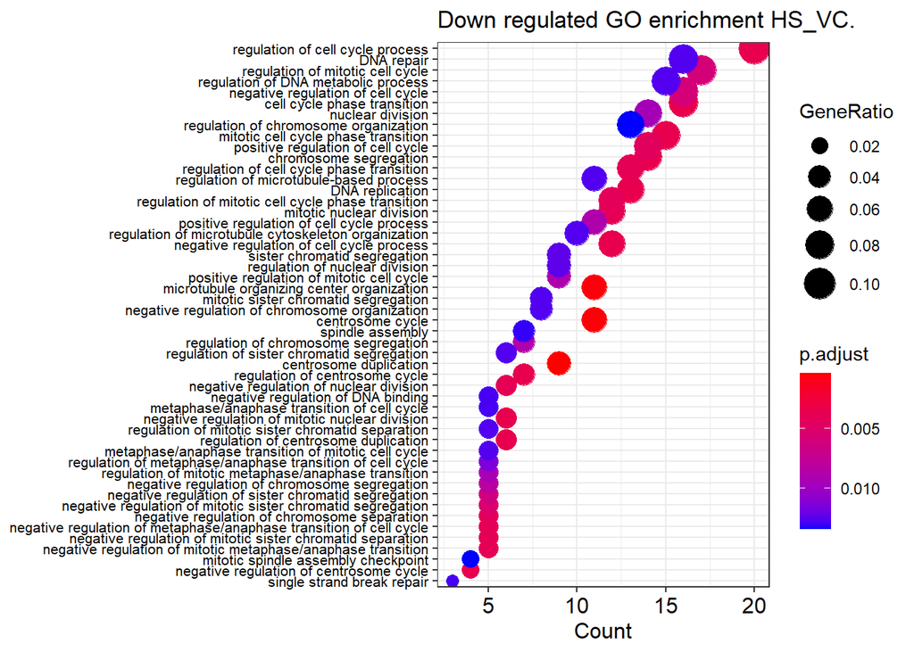

```
## [1] "ENSMUSG00000074194: Zinc finger-cellular response to DNA damage stimulus"
```

```
## [1] "ENSMUSG00000032343: inter photoreceptor- visual perception"
```

```
## [1] "ENSMUSG00000079184: M phase phosphoprotein- trancription (DNA methylated binding)"
```

```
## [1] "ENSMUSG00000027104: ATF-2- transcription activator (Adipocytes functions)"
```

```
## [1] "ENSMUSG00000030849: fibroblast growth factor receptor 2: cellular response to transforming growth factor beta stimulus"
```

```
## [1] "ENSMUSG00000023806: radial spoke 3B homolog biological process,May serve as a point of convergence for MAPK and PKA signaling"
```

```
## [1] "ENSMUSG00000092909: miRNA no GO"
```

```
## [1] "ENSMUSG00000021665: hexosaminidasa B metabolism,fertilization..."
```

```
## [1] "ENSMUSG00000043719: Collagen cell adhesion"
```

```
## [1] "ENSMUSG00000073471: radial spoke 3A homolog,May serve as a point of convergence for MAPK and PKA signalin "
```

```r
no_dup<-which(duplicated(DownDGE.HS_VC)== FALSE)
DownDGE.HS_VC<-DownDGE.HS_VC[no_dup]

egoHS_VC<-enrichGO(gene = as.character(DownDGE.HS_VC),
                   universe = allOE_genes,
                   keyType = "ENSEMBL",
                   OrgDb =org.Mm.eg.db,
                   ont = "BP",
                   pAdjustMethod = "BH",
                   qvalueCutoff = 0.05,
                   readable = T)

Summ.ego.Down.HS_VC<-data.frame(egoHS_VC)

dotplot(object=egoHS_VC,x="count",orderBy="BgRatio",showCategory=50) + theme(axis.text.y = element_text(size = 7.7))+ ggtitle("Down regulated GO enrichment HS_VC.")
```

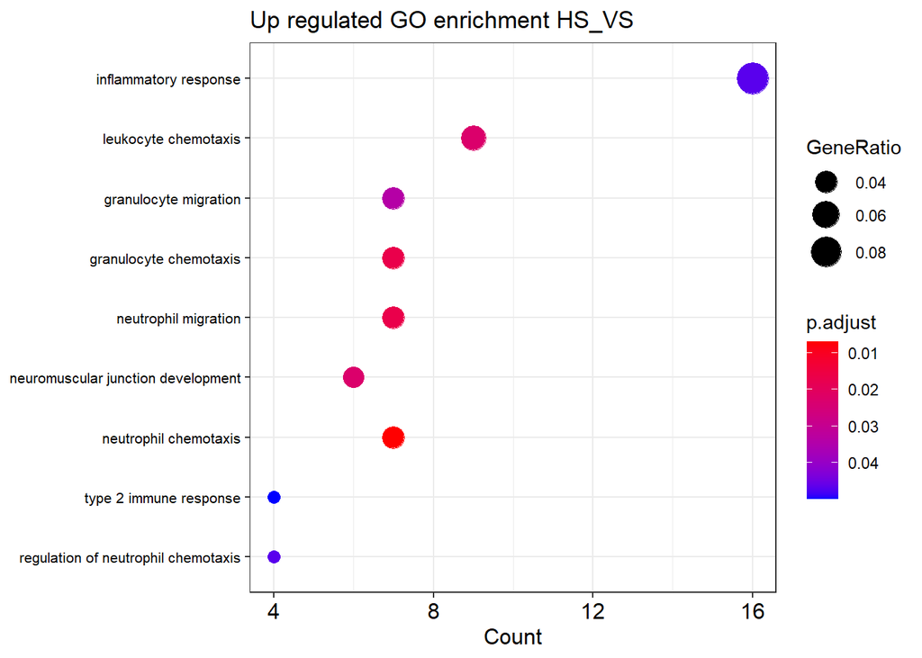

```r
no_dup<-which(duplicated(UpDGE.HS_VS)== FALSE)
UpDGE.HS_VS<-UpDGE.HS_VS[no_dup]

egoHS_VS<-enrichGO(gene = as.character(UpDGE.HS_VS),
                   universe = allOE_genes,
                   keyType = "ENSEMBL",
                   OrgDb =org.Mm.eg.db,
                   ont = "BP",
                   pAdjustMethod = "BH",
                   qvalueCutoff = 0.05,
                   readable = T)

Summ.ego.Up.HS_VS<-data.frame(egoHS_VS)

dotplot(object=egoHS_VS,x="count",orderBy="BgRatio",showCategory=50)+ theme(axis.text.y = element_text(size = 7.7)) + ggtitle("Up regulated GO enrichment HS_VS")
```

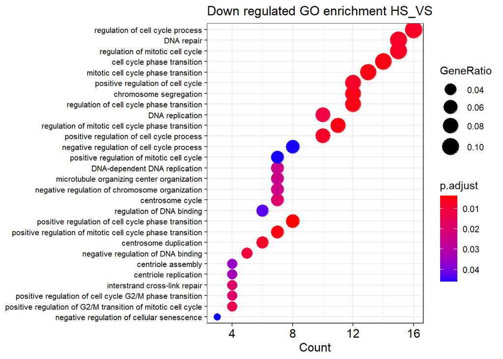

```r
no_dup<-which(duplicated(DownDGE.HS_VS)== FALSE)
DownDGE.HS_VS<-DownDGE.HS_VS[no_dup]

egoHS_VS<-enrichGO(gene = as.character(DownDGE.HS_VS),
                   universe = allOE_genes,
                   keyType = "ENSEMBL",
                   OrgDb =org.Mm.eg.db,
                   ont = "BP",
                   pAdjustMethod = "BH",
                   qvalueCutoff = 0.05,
                   readable = T)

Summ.ego.Down.HS_VS<-data.frame(egoHS_VS)

dotplot(object=egoHS_VS,x="count",orderBy="BgRatio",showCategory=50)+ theme(axis.text.y = element_text(size = 7.7)) +  ggtitle("Down regulated GO enrichment HS_VS")
```

## Second Diferential expression analysis

Now the next comparations will be adressed:

*Primed(HC) vs Control(VC)

*Primed/Activated (VS) vs Control (VC)

*Control (Str) vs Control (Hpp)

**Natural Activation in Str vs Hpp

```r
contrast2<- makeContrasts(
  "Primed_Control"="Hpp_Hi_Con - Hpp_Vh_Con",
  "PrimAct_Control"="Hpp_Vh_Sho - Hpp_Vh_Con",
  "CStr_CHpp"="Str_Vh_Con - Hpp_Vh_Con",
  "NatAcStr_NatAcHpp"="Str_Vh_Sho - Hpp_Vh_Sho",
  levels = dge85$design
)

contrast.HC_VC<- contrast2[,1]
contrast.VS_VC<-contrast2[,2]
contrast.Str_Hpp<-contrast2[,3]
contrast.AcStr_Hpp<-contrast2[,4]
```

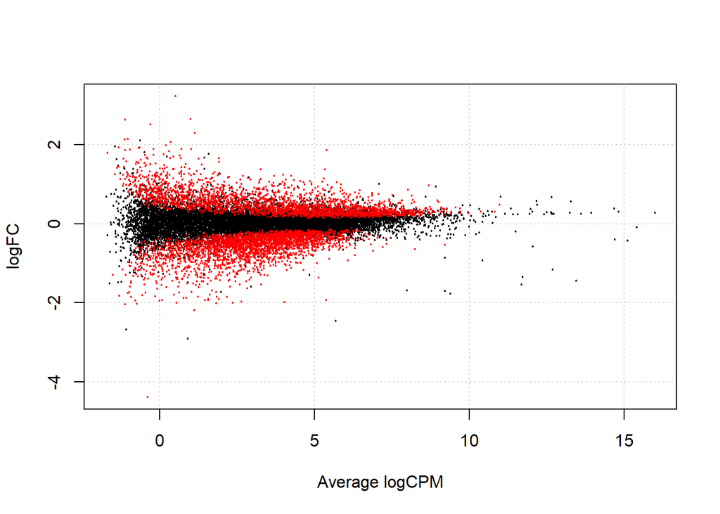

```r
LFTHC_VC<-glmQLFTest(glm,contrast =  contrast.HC_VC)
LFTVS_VC<-glmQLFTest(glm2,contrast =  contrast.VS_VC)
LFTStr_Hpp<-glmQLFTest(glm,contrast =  contrast.Str_Hpp)
LFTAcStr_AcHpp<-glmQLFTest(glm, contrast = contrast.AcStr_Hpp)

dt.HC_VC<-decideTestsDGE(LFTHC_VC,adjust.method = "BH",p.value = 0.05,lfc = 0)
deGenes<- rownames(LFTHC_VC)[dt.HC_VC !=0]
plotSmear(LFTHC_VC,de.tags = deGenes)
```

```r
table(dt.HC_VC)
```

```
## dt.HC_VC
##    -1     0     1
##  2921 13772  2548
```

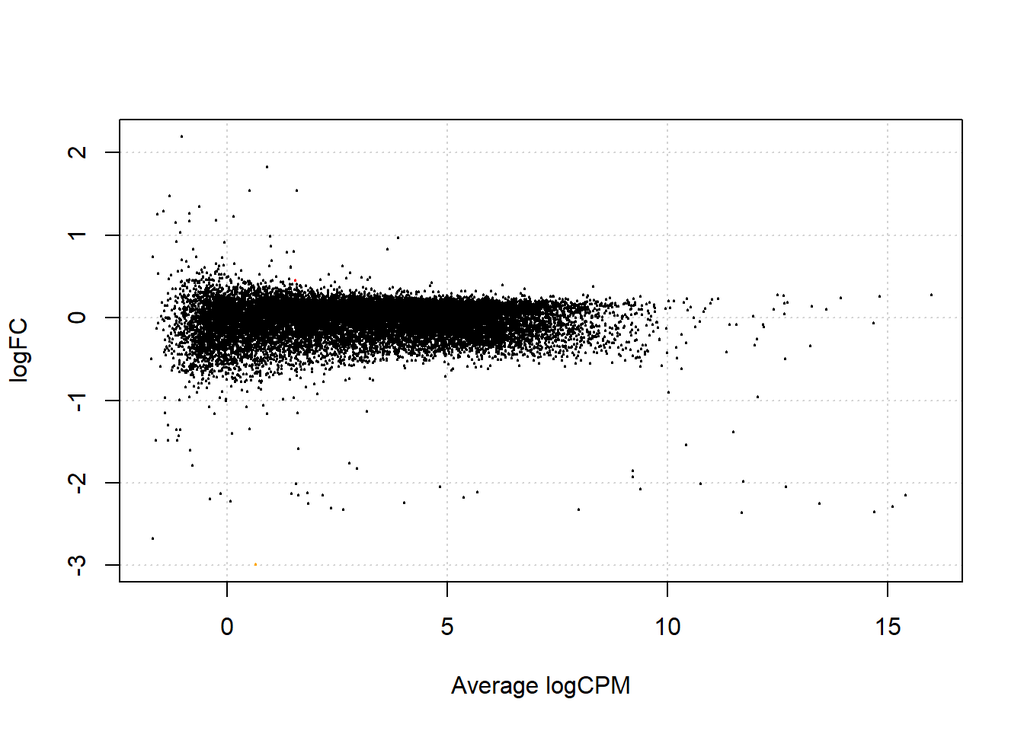

```r
dt.VS_VC<-decideTestsDGE(LFTVS_VC,adjust.method = "BH",p.value = 0.05,lfc = 0)
deGenes<- rownames(LFTVS_VC)[dt.VS_VC !=0]
plotSmear(LFTVS_VC,de.tags = deGenes)
```

```r
table(dt.VS_VC)
```

```
## dt.VS_VC
##     0     1
## 19240     1
```

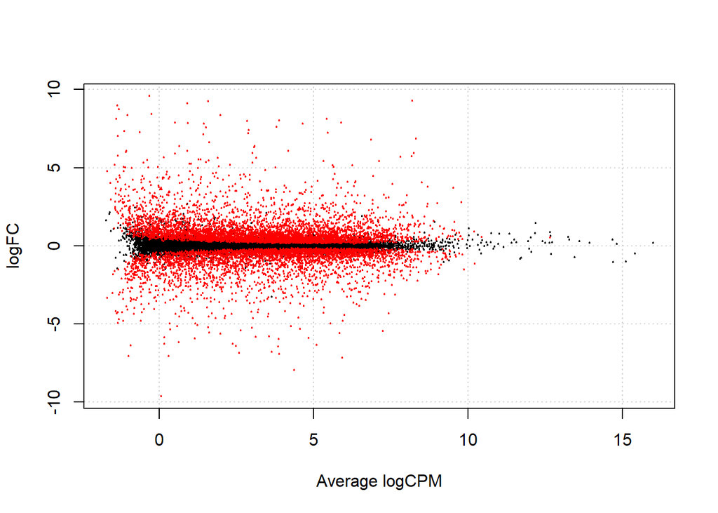

```r
dt.Str_Hpp<-decideTestsDGE(LFTStr_Hpp,adjust.method = "BH",p.value = 0.05,lfc = 0)
deGenes<- rownames(LFTStr_Hpp)[dt.Str_Hpp !=0]
plotSmear(LFTStr_Hpp,de.tags = deGenes)
```

```r
table(dt.Str_Hpp)
```

```
## dt.Str_Hpp
##    -1     0     1
##  3556 10901  4784
```

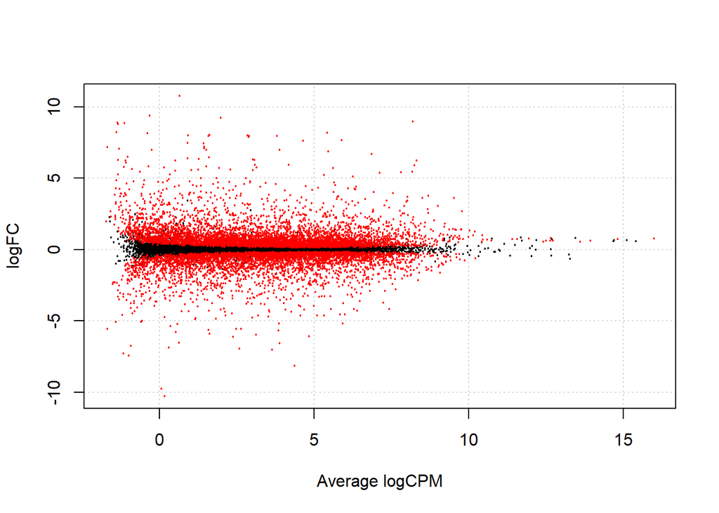

```r
dt.AcStr_AcHpp<-decideTestsDGE(LFTAcStr_AcHpp,adjust.method = "BH",p.value = 0.05,lfc = 0)
deGenes<- rownames(LFTAcStr_AcHpp)[dt.AcStr_AcHpp !=0]
plotSmear(LFTAcStr_AcHpp,de.tags = deGenes)
```

```r
table(dt.AcStr_AcHpp)
```

```
## dt.AcStr_AcHpp
##   -1    0    1
## 4250 9374 5617
```

```r
DGE.HC_VC<-topTags(LFTHC_VC,n=Inf)$table
DGE.HC_VC$ensembl_gene_id<-row.names(DGE.HC_VC)
DGE.HC_VC<-merge(DGE.HC_VC,Genes,by="ensembl_gene_id")
write.csv(DGE.HC_VC,"DGE.HC_VC.csv")
head(DGE.HC_VC)
```

```
##      ensembl_gene_id       logFC    logCPM          F       PValue         FDR
## 1 ENSMUSG00000000001 -0.11019031 4.7546566  1.2686286 0.2698730019 0.424372869
## 2 ENSMUSG00000000028 -0.35951819 0.2308655  4.4590972 0.0440508831 0.117345015
## 3 ENSMUSG00000000037 -0.82485783 0.4179607 15.2347416 0.0005665593 0.004163929
## 4 ENSMUSG00000000049  0.29304644 1.7256776  3.8187222 0.0610455505 0.149380318
## 5 ENSMUSG00000000056 -0.04256035 5.1346188  0.1482405 0.7032196601 0.806499939
## 6 ENSMUSG00000000058  0.29080449 3.2441450  3.2852963 0.0809938172 0.182632373
##   external_gene_name
## 1              Gnai3
## 2              Cdc45
## 3              Scml2
## 4               Apoh
## 5               Narf
## 6               Cav2
```

```r
DGE.VS_VC<-topTags(LFTVS_VC,n=Inf)$table
DGE.VS_VC$ensembl_gene_id<-row.names(DGE.VS_VC)
DGE.VS_VC<-merge(DGE.VS_VC,Genes,by="ensembl_gene_id")
write.csv(DGE.VS_VC,"DGE.VS_VC.csv")
head(DGE.VS_VC)
```

```
##      ensembl_gene_id       logFC    logCPM          F     PValue       FDR
## 1 ENSMUSG00000000001 -0.16519759 4.7546566 2.85154534 0.09128686 0.4833710
## 2 ENSMUSG00000000028 -0.02914075 0.2308655 0.03047985 0.86140599 0.9487300
## 3 ENSMUSG00000000037 -0.46973414 0.4179607 5.51923454 0.01880892 0.3633404
## 4 ENSMUSG00000000049 -0.02557166 1.7256776 0.02841466 0.86613773 0.9495920
## 5 ENSMUSG00000000056  0.02806880 5.1346188 0.06479068 0.79907842 0.9205463
## 6 ENSMUSG00000000058 -0.07409765 3.2441450 0.22215963 0.63739952 0.8405321
##   external_gene_name
## 1              Gnai3
## 2              Cdc45
## 3              Scml2
## 4               Apoh
## 5               Narf
## 6               Cav2
```

```r
DGE.Str_Hpp<-topTags(LFTStr_Hpp,n=Inf)$table
DGE.Str_Hpp$ensembl_gene_id<-row.names(DGE.Str_Hpp)
DGE.Str_Hpp<-merge(DGE.Str_Hpp,Genes,by="ensembl_gene_id")
write.csv(DGE.Str_Hpp,"DGE.Str_Hpp.csv")
head(DGE.Str_Hpp)
```

```
##      ensembl_gene_id      logFC    logCPM          F       PValue          FDR
## 1 ENSMUSG00000000001 -0.1460135 4.7546566  1.9029653 1.789942e-01 2.774532e-01
## 2 ENSMUSG00000000028 -0.1708035 0.2308655  0.8820705 3.559090e-01 4.748333e-01
## 3 ENSMUSG00000000037 -0.2090978 0.4179607  0.8900248 3.537834e-01 4.729155e-01
## 4 ENSMUSG00000000049 -1.0410989 1.7256776 37.4757209 1.495236e-06 1.158672e-05
## 5 ENSMUSG00000000056  0.3601938 5.1346188  9.2300514 5.210395e-03 1.492085e-02
## 6 ENSMUSG00000000058 -0.9106317 3.2441450 25.8385584 2.409969e-05 1.361028e-04
##   external_gene_name
## 1              Gnai3
## 2              Cdc45
## 3              Scml2
## 4               Apoh
## 5               Narf
## 6               Cav2
```

```r
DGE.AcStr_AcHpp<-topTags(LFTAcStr_AcHpp,n=Inf)$table
DGE.AcStr_AcHpp$ensembl_gene_id<-row.names(DGE.AcStr_AcHpp)
DGE.AcStr_AcHpp<-merge(DGE.AcStr_AcHpp,Genes,by="ensembl_gene_id")
write.csv(DGE.AcStr_AcHpp,"DGE.AcStr_AcHpp.csv")
head(DGE.AcStr_AcHpp)
```

```
##      ensembl_gene_id       logFC    logCPM          F       PValue          FDR
## 1 ENSMUSG00000000001  0.05236039 4.7546566  0.2865014 5.968249e-01 6.762164e-01
## 2 ENSMUSG00000000028 -0.28780966 0.2308655  2.8950912 1.002664e-01 1.577411e-01
## 3 ENSMUSG00000000037  0.26832915 0.4179607  1.6737150 2.066505e-01 2.876275e-01
## 4 ENSMUSG00000000049 -0.94334673 1.7256776 37.1393975 1.607771e-06 1.059422e-05
## 5 ENSMUSG00000000056  0.24147375 5.1346188  4.7850606 3.748480e-02 6.900546e-02
## 6 ENSMUSG00000000058 -0.72633301 3.2441450 19.8545473 1.303570e-04 5.092788e-04
##   external_gene_name
## 1              Gnai3
## 2              Cdc45
## 3              Scml2
## 4               Apoh
## 5               Narf
## 6               Cav2
```

## GO enrichment analysis 2.

```r
UpDGE.HC_VC<-DGE.HC_VC[DGE.HS_VC$logFC>=1 & DGE.HC_VC$FDR <0.05,]$ensembl_gene_id
length(UpDGE.HC_VC)
```

```
## [1] 213
```

```r
#write(UpDGE.HC_VC,"UpDGE.HC_VC.txt")
UpDGE.Str_Hpp<-DGE.Str_Hpp[DGE.Str_Hpp$logFC>=1 & DGE.Str_Hpp$FDR <0.05,]$ensembl_gene_id
UpDGE.AcStr_AcHpp<-DGE.AcStr_AcHpp[DGE.AcStr_AcHpp$logFC>=1 & DGE.AcStr_AcHpp$FDR <0.05,]$ensembl_gene_id
DownDGE.HC_VC<-DGE.HC_VC[DGE.HS_VC$logFC<=-1 & DGE.HC_VC$FDR <0.05,]$ensembl_gene_id
length(DownDGE.HC_VC)
```

```
## [1] 282
```

```r
#write(DownDGE.HC_VC,"DownDGE.HC_VC.txt")
DownDGE.Str_Hpp<-DGE.Str_Hpp[DGE.Str_Hpp$logFC<=-1 & DGE.Str_Hpp$FDR <0.05,]$ensembl_gene_id
DownDGE.AcStr_AcHpp<-DGE.AcStr_AcHpp[DGE.AcStr_AcHpp$logFC<=-1 & DGE.AcStr_AcHpp$FDR <0.05,]$ensembl_gene_id
```

Due to the amunt of both Up and Down DEG, the enrichment can't yield a result. To analyze this set of genes another GO enrichment tool will be used, WebGestalt.

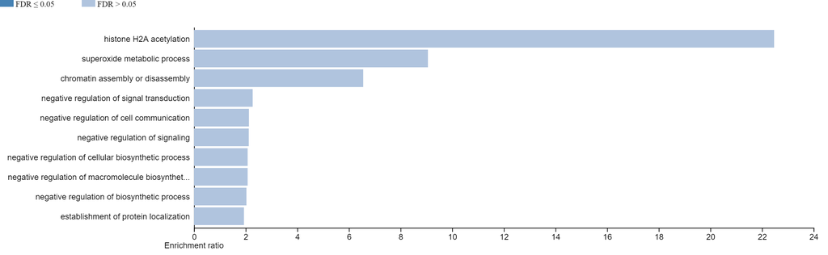

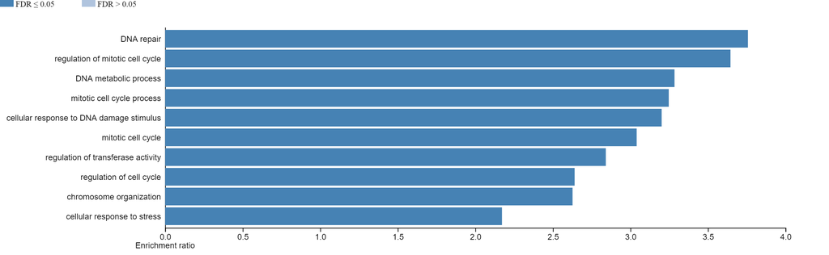

For the VS_VC comparison just one gene was retrieved with acceptable p value and flase discovery rate. ENSMUSG00000049686 is the ensemble ID for ORAI gene, a calcium modulator that is cathaloged in calcium influx and transport.

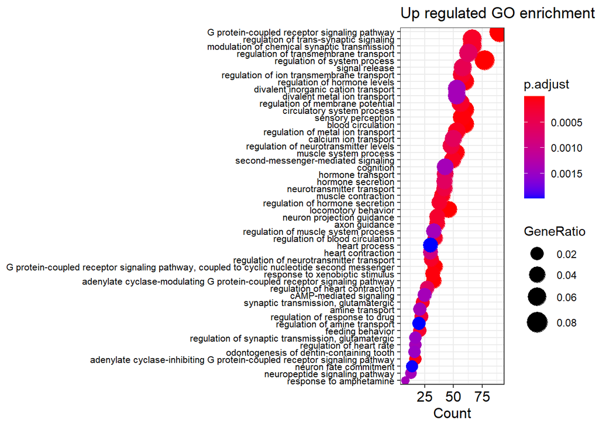

```r
no_dup<-which(duplicated(UpDGE.Str_Hpp)== FALSE)
UpDGE.Str_Hpp<-UpDGE.Str_Hpp[no_dup]


egoStr_Hpp<-enrichGO(gene = as.character(UpDGE.Str_Hpp),
                   universe = allOE_genes,
                   keyType = "ENSEMBL",
                   OrgDb =org.Mm.eg.db,
                   ont = "BP",
                   pAdjustMethod = "BH",
                   qvalueCutoff = 0.05,
                   readable = T)

Summ.ego.Up.Str_Hpp<-data.frame(egoStr_Hpp)

dotplot(object=egoStr_Hpp,x="count",orderBy="BgRatio",showCategory=50) + theme(axis.text.y = element_text(size = 7.7))+ ggtitle("Up regulated GO enrichment Str_Hpp.")
```